# Integrating paired flow cytometry and CyTOF data

Christina Bligaard Pedersen

February 17, 2021

This vignette will demonstrate the integration of paired flow cytometry and CyTOF protein expression measurements using cyCombine.

First, let us present the datasets we will integrate:

These datasets are from the article by [Oetjen et al. (2018)](https://doi.org/10.1172/jci.insight.124928). The data is from bone marrow aspirations from healthy donors. Originally, five flow cytometry panels were applied on 20 donors, and a mass cytometry panel was used for 8 of these samples.

We downloaded the FCS files for the 8 CyTOF samples and the T cell flow cytometry panel (the 8 paired donors) from FlowRepository (FR-FCM-ZYQ9, FR-FCM-ZYQB). Both datasets were pre-gated to live, intact singlet cells and exported as FCS files.

#### Preparing data

We start by loading some packages.

```r
library(cyCombine)
library(tidyverse)
```

We are now ready to load the flow data. We have set up a panel file in csv format, so the correct information is extractable from there. Let us have a look at the contents:

```r
# Directory with raw .fcs files
data_dir <- "Oetjen_et_al_2018-Singlet-Live"

# Panel and reading data
flow_panel <- read_csv('flow_panel_T.csv')
flow_panel
```

| Channel | Marker | Type |
| --- | --- | --- |
| FSC-A | FSC-A | none |
| FSC-H | FSC-H | none |
| FSC-W | FSC-W | none |
| SSC-A | SSC-A | none |
| SSC-H | SSC-H | none |
| SSC-W | SSC-W | none |
| R660-A | CD95 | type |
| R780-A | CD8 | type |
| B515-A | CD27 | type |
| B710-A | CXCR4 | type |

[output cut: 10 more lines]

We then progress with reading the flow dataset and converting it to a tibble format, which is easy to process. We use cofactor = 150 for flow cytometry data asinh-transformation.

```r
flow_markers <- flow_panel %>%
  filter(Type != "none") %>%
  pull(Marker) %>%
  str_remove_all("[ _-]")

flow <- prepare_data(data_dir = data_dir,
                     metadata = "metadata.xlsx",
                     filename_col = "FileName_T",
                     batch_ids = "Batch",
                     cofactor = 150,
                     derand = FALSE,
                     sample_ids = 'SampleID',
                     markers = flow_markers,
                     down_sample = FALSE)
```

```
Reading 8 files to a flowSet..
```

```
Extracting expression data..
```

```
Your flowset is now converted into a dataframe.
```

```
Transforming data using asinh with a cofactor of 150..
```

```
Done!
```

Then it is time to read the CyTOF data.

```r
# Directory with raw .fcs files
data_dir <- "Oetjen_et_al_2018_CyTOF"

# Panel and reading data
cytof_panel <- read_csv('cytof_panel.csv')

cytof_markers <- cytof_panel %>%
  filter(Type != "none") %>%
  pull(Marker) %>%
  str_remove_all("[ _-]")

cytof <- prepare_data(data_dir = data_dir,
                      metadata = "metadata.xlsx",
                      filename_col = "FileName_T",
                      batch_ids = "Batch",
                      cofactor = 5,
                      sample_ids = 'SampleID',
                      markers = cytof_markers,
                      down_sample = FALSE)
```

#### Processing data together - batch correction

Next, we need to figure out which markers to use when integrating the two datasets.

Be careful with protein names - I.e. in CyTOF, the column name is CD95FAS - in flow it is CD95.

```r
colnames(cytof)[colnames(cytof)=='CD95FAS'] <- 'CD95'
colnames(cytof)[colnames(cytof)=='CD8a'] <- 'CD8'
colnames(cytof)[colnames(cytof)=='CD197'] <- 'CCR7'
```

Now, we are ready to combine the two datasets on the overlapping columns.

```r
# Get overlapping column names
overlap_cols <- intersect(colnames(flow), colnames(cytof))

# Make one tibble
uncorrected <- bind_rows(cytof[,overlap_cols], flow[,overlap_cols]) %>%
  mutate(id = 1:(nrow(cytof)+nrow(flow)))
```

And now, batch correction can be performed with cyCombine.

```r
# Run batch correction
corrected <- uncorrected %>%
  batch_correct(xdim = 8,
                ydim = 8,
                norm_method = 'rank',
                ties.method = 'average',
                rlen = 100)
```

#### Evaluating performance

We now evaluate the correction using EMD - each marker is evaluated across all cells.

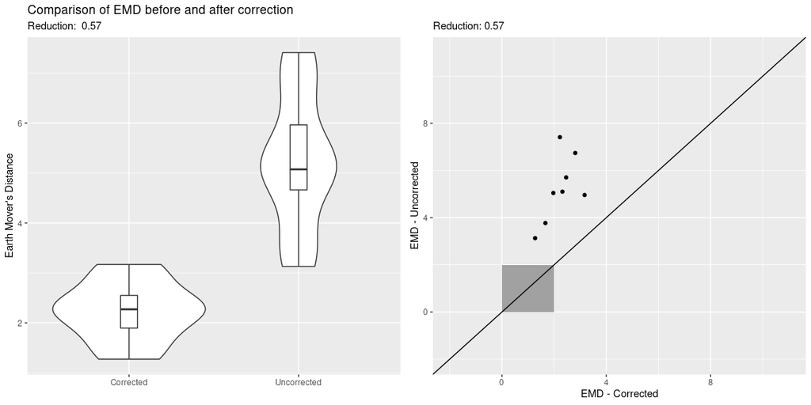

```r
corrected$label <- uncorrected$label <- 1

emd <- evaluate_emd(uncorrected = uncorrected,
                    corrected = corrected)

cowplot::plot_grid(emd$violin, emd$scatterplot)
```

Let us look at some plots to visualize the correction. First, the marker distributions before and after:

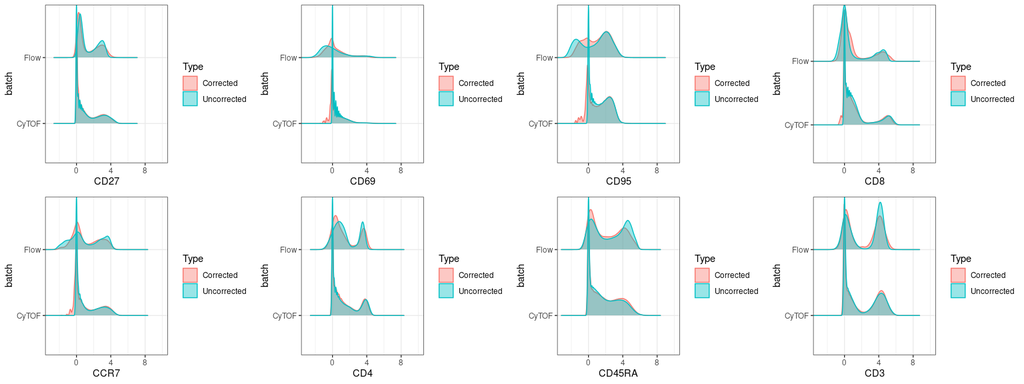

```r
plot_density(uncorrected, corrected, ncol = 4, xlims = c(-3,10))
```

And now some UMAPs to visualize the correction. I will downsample to 10,000 cells from each dataset so it is easier to see what is going on.

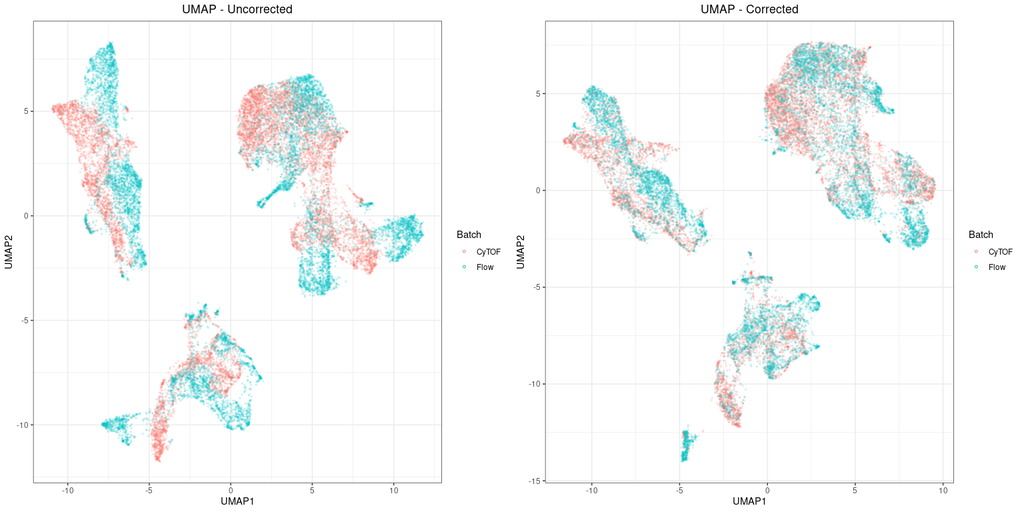

```r
inds <- split(1:length(uncorrected$batch), uncorrected$batch)
sample <- unlist(lapply(inds, sample, 10000))

plot1 <- plot_dimred(uncorrected[sample,], name = 'Uncorrected', type = 'umap')
plot2 <- plot_dimred(corrected[sample,], name = 'Corrected', type = 'umap')

cowplot::plot_grid(plot1, plot2)
```

Based on the UMAP, it seems like the datasets each contain three major clusters. This is also the case after correction.

Since we actually have paired samples in this dataset, it is possible to make a direct comparison - first we will co-cluster the data using FlowSOM.

```r
# Clustering with 3x3 SOM grid
som_ <- corrected %>%
  cyCombine::create_som(seed = 48,
                        xdim = 3,
                        ydim = 3)
```

```
Creating SOM grid..
```

```r
# Saving labels
corrected$label <- as.factor(som_)
```

Now, let us have a look at the clusters and their expression patterns.

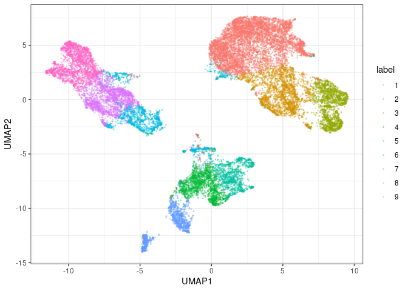

```r
plots <- plot_dimred(corrected[sample,], name = 'Corrected', type = 'umap', plot = 'CD3', return_coord = T)


# We can further include the UMAP coordinates in a combined dataframe with both imputed datasets. Again, we downsample to avoid too many cells cluttering the view (the same indeces are used as before)
combined <- cbind.data.frame(plots$dimred, corrected[sample,])


# Now let us color the plot by the relatively few overlapping markers - and the cluster labels
p <- list()
for (m in c(get_markers(corrected))) {

  p[[m]] <- ggplot(combined, aes_string(x = colnames(combined)[1], y = colnames(combined)[2])) +
  geom_point(aes_string(color = m), alpha = 0.3, size = 0.4) +
  theme_bw() + theme(plot.title = element_text(hjust = 0.5)) +
  scale_color_viridis_c()

}

ggplot(combined, aes_string(x = colnames(combined)[1], y = colnames(combined)[2])) +
  geom_point(aes(color = label), alpha = 0.3, size = 0.4) +
  theme_bw() + theme(plot.title = element_text(hjust = 0.5))
```

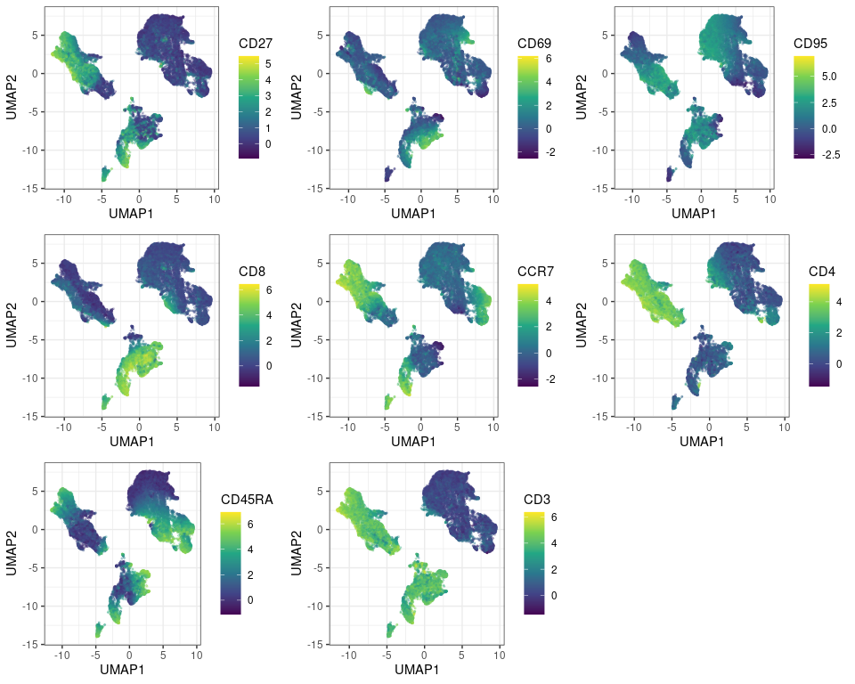

```r
cowplot::plot_grid(plotlist = p, ncol = 3)
```

```r
# Comparing SOM percentages in paired samples
count_table <- table(corrected$sample, corrected$label)

round((count_table/rowSums(count_table)) * 100, 2)
```

```
              1     2     3     4     5     6     7     8     9
  A_CyTOF 28.71  7.90  5.75  9.82 12.21 13.41  2.95  9.22 10.04
  A_Flow  24.94  8.71  4.81 10.70 13.63 16.43  2.02  9.56  9.19
  B_CyTOF 35.05 13.68  7.64  6.67  3.19  2.84  6.57 11.90 12.46
  B_Flow  16.62 25.76 11.58 12.50  7.77  4.54  4.20  9.93  7.08
  C_CyTOF 40.64  9.50 17.10  5.74  1.06  9.03  1.73  8.78  6.41
  C_Flow  30.61 10.20 23.93  7.89  1.84  8.66  1.66  8.67  6.54
  H_CyTOF 27.38 10.92  7.58  7.50  7.79  5.93  7.60 10.48 14.82
  H_Flow  31.04 11.39  7.38  8.94  7.51  6.59  5.07 11.19 10.89
  J_CyTOF 36.07  9.97 10.41  3.80  0.99  6.91 10.69  5.99 15.18
  J_Flow  30.70  9.49 11.99  5.57  1.23  2.81 11.57  9.63 17.02
  O_CyTOF 43.73 10.48  4.83  8.39  6.24  8.75  5.49  7.78  4.31
  O_Flow   6.20 15.92  8.88 13.78 15.04 14.18  8.12 10.93  6.94
  T_CyTOF 42.37 13.82  8.51  5.46  2.92  6.72  8.87  6.42  4.90
  T_Flow  41.66 21.15 10.16  4.61  3.87  6.56  5.84  2.56  3.59
  U_CyTOF 26.95 12.48 14.09  6.35  0.80 10.18  7.20 10.61 11.34
  U_Flow  23.00 10.76 15.63  7.84  0.89  4.23  4.82 22.99  9.84
```

Here, it is seen that the sample cell type fractions correlate nicely with the counterpart from the other technology. However, we do have some clusters, e.g. cluster 1, where the fractions tend to be larger for one technology.